# introduction

Wen Ma

2020-01-02

# Overview

**SC19023** is a simple R package developed to compare the performance of R and R++ (implemented through the R package *Rcpp*) for the homework of ‘Statistical Computing’ course.Two functions are considered, namely, *linear_reg* (Regression analysis on centralized data) and *Metropolis* (Implement the random walk version of the Metropolis sampler to generate the target distribution N(Xt,sigma^2)). For the second function, both R and Rcpp versions are produced. Namely *MetropolisR* for R and *MetropolisC* for C++.

The R package ‘microbenchmark’ can be used to benchmark the above R and C++ functions.

## Use *linear_reg* to perform regression analysis on centralized data

The source R code for *linear_reg* is as follows

```r
linear_reg <- function(formula, data){
  x <- scale(data)
  result <- lm(formula, x)
  return(result)
}
```

## Benchmarking *MetropolisR* and *MetropolisC*

The source R code for *MetropolisR* is as follows:

```r
rwMetropolisR <- function(sigma, x0, N) {
  x <- numeric(N)
  x[1] <- x0
  u <- runif(N)
  k <- 0
  for (i in 2:N) {
    y <- rnorm(1, x[i-1], sigma)
    if (u[i] <= exp(abs(x[i-1]) - abs(y)))
      x[i] <- y else {
        x[i] <- x[i-1]
        k <- k + 1
      }
  }
  return(list(x=x))
}
```

The following *Rcpp* code takes less computational time than R code.

```r
library(Rcpp)
cppFunction('NumericVector rwMetropolisC(double sigma, double x0, double N) {
  NumericVector x(N+1);
  x[0] = x0;
  NumericVector u = runif(N);
  double k = 0;
  double y = 0;
  for (int i = 2; i < N+1; i++) {
    y = rnorm(1, x[i-2], sigma)[0];
    if (u[i-2] <= exp(-((abs(y))-(abs(x[i-2])))) ) {
      x[i-1] = y;
    }
    else {
      x[i-1] = x[i-2];
      k++;
    }
  }
  x[N] = k;
  return(x);
}')
```

The R code for benchmarking *MetropolisR* and *MetropolisC* is as follows.

```r
library(SC19023)
library(microbenchmark)

tm <- microbenchmark(
  vR = rwMetropolisR( .5, 25, 2000),
  vC = rwMetropolisC( .5, 25, 2000))
knitr::kable(summary(tm)[, c(1,3,5,6)])
```

| expr | lq | median | uq |
| --- | --- | --- | --- |
| vR | 3302.05 | 3315.65 | 3362.30 |
| vC | 188.95 | 191.95 | 195.75 |

The results again show an evident computational speed gain of C++ against R.

# A-19023-2019-09-25

## Question

Use knitr to produce at least 3 examples (texts, figures, tables)

## Answer

text

```r
a <- "Hello,USTC!"
print(a)
```

```
## [1] "Hello,USTC!"
```

figures

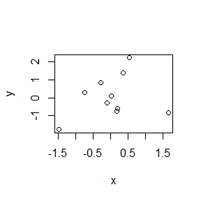

```r
x <- rnorm(10)
y <- rnorm(10)
plot(x,y)
```

table

```r
m <- 1:4;n <- 8
data.frame(m,n)
```

```
##   m n
## 1 1 8
## 2 2 8
## 3 3 8
## 4 4 8
```

# A-19023-2019-09-29

## Qustion 1

3.4 The Rayleigh density [156, Ch. 18] is

f(x) = x/σ2 * exp(−x^2/(2*σ^2)), x ≥ 0, σ > 0.

Develop an algorithm to generate random samples from a Rayleigh(σ) distribution. Generate Rayleigh(σ) samples for several choices of σ > 0 and check that the mode of the generated samples is close to the theoretical mode σ(check the histogram).

## Answer

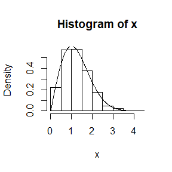

```r
n <- 1000
u <- runif(n)
sigma <- c(1)
x <- {-2*sigma*log(1-u)}^(1/2) #F(x)=1-exp{-x^2/2*sigma^2}
hist(x,prob=TRUE)
y <- seq(0,4, .01)
lines(y,exp(-1*y^2/2*sigma^2)*y/sigma^2)
```

## Qustion 2

3.11 Generate a random sample of size 1000 from a normal location mixture. The components of the mixture have N(0, 1) and N(3, 1) distributions with mixing probabilities p1 and p2 = 1 − p1. Graph the histogram of the sample with density superimposed, for p1 = 0.75. Repeat with different values for p1 and observe whether the empirical distribution of the mixture appears to be bimodal. Make a conjecture about the values of p1 that produce bimodal mixtures.

## Answer

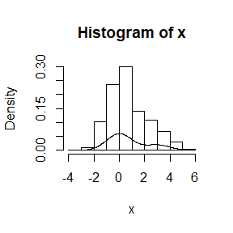

```r
n <- 1000
x1 <- rnorm(n,0,1)
x2 <- rnorm(n,3,1)
u <- runif(n)
k <- as.integer(u>0.25)
x <- k * x1 + (1-k) * x2
hist(x, prob=TRUE)
y <- seq(-4,6, .01)
lines(y,0.75/(2*pi)^1/2*exp(-y^2/2)+0.25/(2*pi)^1/2*exp(-(y-3)^2/2))
```

## Qustion 3

3.18 Write a function to generate a random sample from a Wd(Σ, n) (Wishart) distribution for n > d + 1 ≥ 1, based on Bartlett’s decomposition.

## Answer

```r
n <- 1000
```

# A-19023-2019-10-11

## Qustion 1

5.1 Compute a Monte Carlo estimate of
$$\int_0^{π/3} sint {\rm d}t$$
and compare your estimate with the exact value of the integral.

## Answer

```r
m <- 10000
x <- runif(m, min=0, max=(pi/3))
theta.hat <- mean(sin(x)) * (pi/3)
print(theta.hat)
```

```
## [1] 0.4990493
```

```r
print(1 - cos(pi/3))
```

```
## [1] 0.5
```

## Qustion 2

5.10 Use Monte Carlo integration with antithetic variables to estimate
$$\int_0^1 \frac{e^{-x}}{1+x^2}{\rm d}x$$
and find the approximate reduction in variance as a percentage of the variance without variance reduction.

## Answer

```r
R <- 10000
u <- runif(R/2)
v <- 1 - u
g1 <- exp(-u)/(1+u^2)
g2 <- exp(-v)/(1+v^2)
theta.hat1 <- mean((g1+g2)/2)
theta.hat1
```

```
## [1] 0.5250741
```

A comparison of estimates obtained from a single Monte Carlo experiment is below.

```r
M <- 10000
x <- runif(M)
f <- exp(-x)/(1+x^2)
theta.hat2 <- mean(f)
theta.hat2
```

```
## [1] 0.5243494
```

The approximate reduction in variance can be estimated by a simulation under both methods, the simple Monte Carlo integration approach and the antithetic variable approach.

```r
m <- 1000
theta.hat1 <- theta.hat2 <- numeric(m)
var_theta.hat1 <- (sd(g1)+sd(g2)+cov(g1,g2))/4
var_theta.hat2 <- sd(f)
print (var_theta.hat1)
```

```
## [1] 0.1083884
```

```r
print (var_theta.hat2)
```

```
## [1] 0.2459217
```

```r
print((var_theta.hat2 - var_theta.hat1)/var_theta.hat2)
```

```
## [1] 0.5592564
```

## Qustion 3

5.15 Obtain the stratified importance sampling estimate in Example 5.13 and compare it with the result of Example 5.10.

Example 5.13 In Example 5.10 our best result was obtained with importance function $f_3(x) = e^{−x}/(1 − e^{−1}), 0 < x < 1$ .From 10000 replicates we obtained the estimate θˆ = 0.5257801 and an estimated standard error 0.0970314. Now divide the interval (0,1) into five subintervals, $(j/5, (j + 1)/5), j = 0, 1, . . . , 4$. Then on the $j^{th}$ subinterval variables are generated from the density
$$\frac{5e^{-1}}{1-e^{-1}},\frac{j-1}{5}<x<\frac{j}{5}$$

## Answer

```r
M <- 5000 #number of replicates
k <- 5 #number of strata
r <- M / k #replicates per stratum
N <- 50 #number of times to repeat the estimation
T2 <- numeric(k)
estimates <- matrix(0, N, 2)

g <- function(x) {
exp(-x - log(1+x^2)) * (x > 0) * (x < 1)
}

fg <- function(x) {
g(x)/(exp(-x) / (1 - exp(-1)) * (x > 0) * (x < 1))
}

for (i in 1:N) {
  estimates[i, 1] <- mean(fg(runif(M)))
  for (j in 1:k)
    T2[j] <- mean(fg(runif(M/k, (j-1)/k, j/k)))
  estimates[i, 2] <- mean(T2)
}
```

The result of this simulation produces the following estimates.

```r
apply(estimates, 2, mean)
```

```
## [1] 0.4965452 0.4964436
```

```r
apply(estimates, 2, var)
```

```
## [1] 1.831949e-06 4.999807e-08
```

# A-19023-2019-10-18

## Qustion 1

$6.5$ Suppose a $95\%$ symmetric t-interval is applied to estimate a mean, but the sample data are non-normal. Then the probability that the confidence interval covers the mean is not necessarily equal to $0.95$. Use a Monte Carlo experiment to estimate the coverage probability of the t-interval for random samples of $\chi^2(2)$ data with sample size $n = 20$. Compare your t-interval results with the simulation results in Example 6.4. (The t-interval should be more robust to departures from normality than the interval for variance.)

## Answer

```r
n <- 20
alpha <-  .05
ULC <- replicate(1000,expr={
  x <- rt(n,df=2)
  (n-1)*var(x)/qchisq(alpha,df=n-1)
})
sum(ULC > 4)
```

```
## [1] 746
```

```r
mean(ULC > 4)
```

```
## [1] 0.746
```

## Qustion 2

$6.6$ Estimate the $0.025, 0.05, 0.95,$ and $0.975$ quantiles of the skewness $\sqrt{b1}$ under normality by a Monte Carlo experiment. Compute the standard error of the estimates from (2.14) using the normal approximation for the density (with exact variance formula). Compare the estimated quantiles with the quantiles of the large sample approximation $\sqrt{b1} ≈ N(0, 6/n)$.

## Answer

Estimate the 0.025, 0.05, 0.95, and 0.975 quantiles of the skewness $\sqrt{b1}$ under normality by a Monte Carlo experiment.

```r
sk <- function(x) {
xbar <- mean(x)
m3 <- mean((x - xbar)^3)
m2 <- mean((x - xbar)^2)
return( m3 / m2^1.5 )
}

m <- 10000
n <- 1000
sqrt.b1 <- numeric(m)
for (j in 1:m) {
x <- rnorm(n)
sqrt.b1[j] <- sk(x)
}

q <- c(0.025,0.05,0.95,0.975)
quantile(sqrt.b1, probs = q)
```

```
##       2.5%         5%        95%      97.5%
## -0.1486398 -0.1257208  0.1297439  0.1545580
```

Quantiles of the large sample approximation $\sqrt{b1} ≈ N(0, 6/n)$

```r
n <- 1000
q <- c(0.025,0.05,0.95,0.975)
cv <- qnorm(q, 0, sqrt(6/n))
cv
```

```
## [1] -0.1518182 -0.1274098  0.1274098  0.1518182
```

The standard error of the estimates from (2.14) using the normal approximation for the density (with exact variance formula)

```r
xq <- as.numeric(quantile(sqrt.b1, probs = q))
sd_sqrt.b1 <- sqrt(6*(n-2)/((n+1)*(n+3)))

sd.hat <- numeric(4)
for(i in 1:4){
f <- dnorm(xq[i], mean = 0, sd = sd_sqrt.b1)
sd.hat[i] <- q[i]*(1-q[i])/(n*f^2)
}

sd.hat
```

```
## [1] 3.711009e-05 2.519757e-05 2.993629e-05 5.013662e-05
```

# A-19023-11-01

## Qustion 1

$6.7$ Estimate the power of the skewness test of normality against symmetric $Beta(α, α)$ distributions and comment on the results. Are the results different for heavy-tailed symmetric alternatives such as $t(ν)$?

## Answer

$Beta(\alpha,\alpha)$

```r
sk <- function(x) {
xbar <- mean(x)
m3 <- mean((x - xbar)^3)
m2 <- mean((x - xbar)^2)
return( m3 / m2^1.5 )
}

b <- .1
n <- 30
m <- 2500
alpha <- c(1:31)
N <- length(alpha)
pwr <- numeric(N)
cv <- qnorm(1-b/2, 0, sqrt(6*(n-2) / ((n+1)*(n+3))))
for (j in 1:N) {
  a <- alpha[j]
  sktests <- numeric(m)
  for (i in 1:m) {
    x <- rbeta(n, a, a)
    sktests[i] <- as.integer(abs(sk(x)) >= cv)
    }
pwr[j] <- mean(sktests)
}

pwr
```

```
##  [1] 0.0164 0.0152 0.0260 0.0380 0.0436 0.0524 0.0512 0.0592 0.0580 0.0600
## [11] 0.0640 0.0804 0.0736 0.0792 0.0692 0.0732 0.0756 0.0784 0.0764 0.0860
## [21] 0.0876 0.0724 0.0880 0.0860 0.0824 0.0868 0.0900 0.0912 0.0768 0.0884
## [31] 0.0908
```

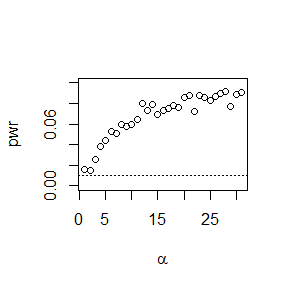

```r
plot(alpha, pwr, type = "b",
xlab = bquote(alpha), ylim = c(0, .1))
abline(h = .01, lty = 3)
```

$t(v)$

```r
sk <- function(x) {
xbar <- mean(x)
m3 <- mean((x - xbar)^3)
m2 <- mean((x - xbar)^2)
return( m3 / m2^1.5 )
}

b <- .1
n <- 30
m <- 2500
v <- c(1:31)
N <- length(v)
pwr <- numeric(N)
cv <- qnorm(1-b/2, 0, sqrt(6*(n-2) / ((n+1)*(n+3))))
for (j in 1:N) {
  a <- as.integer(v[j])
  sktests <- numeric(m)
  for (i in 1:m) {
    x <- rt(n, a)
    sktests[i] <- as.integer(abs(sk(x)) >= cv)
    }
pwr[j] <- mean(sktests)
}

pwr
```

```
##  [1] 0.8716 0.6560 0.4936 0.3988 0.3256 0.2972 0.2472 0.2308 0.2200 0.2004
## [11] 0.1924 0.1832 0.1696 0.1500 0.1492 0.1332 0.1516 0.1524 0.1520 0.1472
## [21] 0.1556 0.1384 0.1444 0.1300 0.1160 0.1264 0.1280 0.1232 0.1348 0.1276
## [31] 0.1288
```

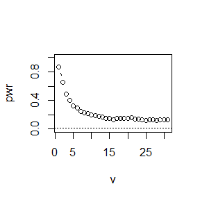

```r
plot(v, pwr, type = "b",
xlab = bquote(v), ylim = c(0,1))
abline(h = .01, lty = 3)
```

## Qustion 2

$6.A$ Use Monte Carlo simulation to investigate whether the empirical Type $I$ error rate of the $t$-test is approximately equal to the nominal significance level $α$, when the sampled population is non-normal. The t-test is robust to mild departures from normality. Discuss the simulation results for the cases where the sampled population is (i) $\chi^2(1)$, (ii) Uniform(0,2), and (iii) Exponential(rate=1). In each case, test $H_0 : \mu = \mu_0$ vs $H_0 : \mu \neq \mu_0$, where $\mu_0$ is the mean of $\chi^2(1)$, Uniform(0,2), and Exponential(1), respectively.

## Answer

$\chi^2(1)$

```r
n <- 20
alpha <- .05
mu0 <- 1
m <- 10000 #number of replicates
I <- numeric(m)
cv1 <- qchisq(1-alpha/2, 1)
cv2 <- qchisq(alpha/2, 1)

for (j in 1:m) {
  chi <- rchisq(n, 1)
  I[j] <- as.integer(chi >= cv1||chi <= cv2)
}
p.hat <- mean(I)
se.hat <- sqrt(p.hat * (1 - p.hat) / m)

print(c(p.hat,se.hat))
```

```
## [1] 0.049900000 0.002177384
```

$Uniform(0,2)$

```r
n <- 20
alpha <- .05
mu0 <- 1
m <- 10000 #number of replicates
I <- numeric(m)
cv1 <- qunif(1-alpha/2, 0, 2)
cv2 <- qunif(alpha/2, 0, 2)

for (j in 1:m) {
  chi <- runif(n, 0, 2)
  I[j] <- as.integer(chi >= cv1||chi <= cv2)
}
p.hat <- mean(I)
se.hat <- sqrt(p.hat * (1 - p.hat) / m)

print(c(p.hat,se.hat))
```

```
## [1] 0.050800000 0.002195891
```

$Exponential(1)$

```r
n <- 20
alpha <- .05
mu0 <- 1
m <- 10000 #number of replicates
I <- numeric(m)
cv1 <- qexp(1-alpha/2, 1)
cv2 <- qexp(alpha/2, 1)

for (j in 1:m) {
  chi <- rexp(n, 1)
  I[j] <- as.integer(chi >= cv1||chi <= cv2)
}
p.hat <- mean(I)
se.hat <- sqrt(p.hat * (1 - p.hat) / m)

print(c(p.hat,se.hat))
```

```
## [1] 0.049700000 0.002173244
```

## Qustion 3

If we obtain the powers for two methods under a particular simulation setting with 10,000 experiments: say, 0.651 for one method and 0.676 for another method. Can we say the powers are different at 0.05 level?

3.1 What is the corresponding hypothesis test problem?

3.2 What test should we use? Z-test, two-sample t-test, paired-t test or McNemar test?

3.3 What information is needed to test your hypothesis?

## Answer 3

3.1 The corresponding hypothesis test problem is:$H_0:\pi(\epsilon_1)=\pi(\epsilon_2);H_1:\pi(\epsilon_1)\neq\pi(\epsilon_2)$

3.2 We should use the two-saple t-test.

3.3 We should know the test statistics for both methods.

# A-19023-2019-11-8

## Qustion 1

$7.6$ Efron and Tibshirani discuss the scor (bootstrap) test score data on 88 students who took examinations in five subjects $[84, Table 7.1], [188,Table 1.2.1]$. The first two tests (mechanics, vectors) were closed book and the last three tests (algebra, analysis, statistics) were open book. Each row of the data frame is a set of scores $(x_{i1},…, x_{i5})$ for the $i^{th}$ student. Use a panel display to display the scatter plots for each pair of test scores. Compare the plot with the sample correlation matrix. Obtain bootstrap estimates of the standard errors for each of the following estimates: $\hatρ_{12} = \hatρ$(mec, vec), $\hatρ_{34} = \hatρ$(alg, ana), $\hatρ_{35} = \hatρ$(alg, sta), $\hatρ_{45} = \hatρ$(ana, sta).

## Answer

$scatter plots$

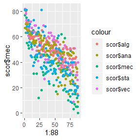

```r
library(bootstrap)
library(ggplot2)

ggplot(data = scor)+
  geom_point(mapping = aes(x = 1:88, y = scor$mec, color="scor$mec"))+
  geom_point(mapping = aes(x = 1:88, y = scor$vec, color="scor$vec"))+
  geom_point(mapping = aes(x = 1:88, y = scor$alg, color="scor$alg"))+
  geom_point(mapping = aes(x = 1:88, y = scor$ana, color="scor$ana"))+
  geom_point(mapping = aes(x = 1:88, y = scor$sta, color="scor$sta"))
```

$\hatρ_{12} , \hatρ_{34}, \hatρ_{35} , \hatρ_{45}$

```r
r12 <- function(x, i) {cor(x[i,1], x[i,2])}
r34 <- function(x, i) {cor(x[i,3], x[i,4])}
r35 <- function(x, i) {cor(x[i,3], x[i,5])}
r45 <- function(x, i) {cor(x[i,4], x[i,5])}


library(boot)
obj12 <- boot(data = scor, statistic = r12, R = 2000)
obj34 <- boot(data = scor, statistic = r34, R = 2000)
obj35 <- boot(data = scor, statistic = r35, R = 2000)
obj45 <- boot(data = scor, statistic = r45, R = 2000)


cor12 <- mean(obj12$t)
cor34 <- mean(obj34$t)
cor35 <- mean(obj35$t)
cor45 <- mean(obj45$t)

c(cor12,cor34,cor35,cor45)
```

```
## [1] 0.5469901 0.7099425 0.6624930 0.6062008
```

## Qustion 2

$7.B$ Repeat Project 7.A for the sample skewness statistic. Compare the coverage rates for normal populations (skewness 0) and $χ^2(5)$ distributions (positive skewness).

## Answer

$N(0,1)$

```r
library(boot)

n <- 100
x <- rnorm(n, 0, 1)

theta.boot <- function(x,i) {
xbar <- mean(x[i])
m3 <- mean((x[i] - xbar)^3)
m2 <- mean((x[i] - xbar)^2)
return( m3 / m2^1.5 )
}

boot.obj1 <- boot(x, R = 2000, statistic = theta.boot)

print(boot.obj1)
```

```
##
## ORDINARY NONPARAMETRIC BOOTSTRAP
##
##
## Call:
## boot(data = x, statistic = theta.boot, R = 2000)
##
##
## Bootstrap Statistics :
##       original     bias    std. error
## t1* -0.4016065 0.01723385   0.1846961
```

```r
print(boot.ci(boot.obj1, type=c("basic","norm","perc")))
```

```
## BOOTSTRAP CONFIDENCE INTERVAL CALCULATIONS
## Based on 2000 bootstrap replicates
##
## CALL :
## boot.ci(boot.out = boot.obj1, type = c("basic", "norm", "perc"))
##
## Intervals :
## Level      Normal              Basic              Percentile
## 95%   (-0.7808, -0.0568 )   (-0.8094, -0.0825 )   (-0.7207,  0.0062 )
## Calculations and Intervals on Original Scale
```

$χ^2(5)$

```r
library(boot)

n <- 100
x <- rchisq(n, 5)

theta.boot <- function(x,i) {
xbar <- mean(x[i])
m3 <- mean((x[i] - xbar)^3)
m2 <- mean((x[i] - xbar)^2)
return( m3 / m2^1.5 )
}

boot.obj2 <- boot(x, R = 2000, statistic = theta.boot)

print(boot.obj2)
```

```
##
## ORDINARY NONPARAMETRIC BOOTSTRAP
##
##
## Call:
## boot(data = x, statistic = theta.boot, R = 2000)
##
##
## Bootstrap Statistics :
##     original      bias    std. error
## t1* 1.243371 -0.03868237   0.2308547
```

```r
print(boot.ci(boot.obj2, type=c("basic","norm","perc")))
```

```
## BOOTSTRAP CONFIDENCE INTERVAL CALCULATIONS
## Based on 2000 bootstrap replicates
##
## CALL :
## boot.ci(boot.out = boot.obj2, type = c("basic", "norm", "perc"))
##
## Intervals :
## Level      Normal              Basic              Percentile
## 95%   ( 0.830,  1.735 )   ( 0.816,  1.704 )   ( 0.783,  1.671 )
## Calculations and Intervals on Original Scale
```

# A-19023-2019-11-15

## Qustion 1

7.8 Refer to Exercise 7.7. Obtain the jackknife estimates of bias and standard error of $\hatθ$.

## Answer

```r
library(bootstrap)
data(scor)
scor_pca <- princomp(scor, cor = F)
scor_pca_summary <- summary(scor_pca)

theta.hat <- 0.619115


n <- nrow(scor)
theta.hat.jackknife <- numeric(n)
for (i in 1:n) {
scor_jackknife <- scor[-i, ]
scor_jackknife_cov <- cov(scor_jackknife)
theta.hat.jackknife[i] <-
eigen(scor_jackknife_cov)$value[1] / sum(eigen(scor_jackknife_cov)$value)
}


bias_theta <- (n - 1) * (mean(theta.hat.jackknife) - theta.hat)


se_theta <- sqrt((n - 1) * mean((theta.hat.jackknife - mean(theta.hat.jackknife)) ^ 2))

output = matrix(0,1,2)
colnames(output) <- c("bias_theta", "se_theta")
output[1,] <- c(bias_theta, se_theta)

output
```

```
##       bias_theta   se_theta
## [1,] 0.001072482 0.04955231
```

## Qustion 2

7.10 In Example 7.18, leave-one-out ($n$-fold) cross validation was used to select the best fitting model. Repeat the analysis replacing the Log-Log model with a cubic polynomial model. Which of the four models is selected by the cross validation procedure? Which model is selected according to maximum adjusted $R^2$?

## Answer

```r
library(DAAG); attach(ironslag)
```

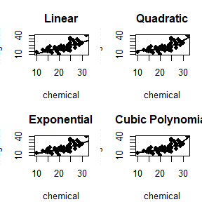

```r
#data(ironslag, package = "DAAG")

a <- seq(10, 40, .1)

par(mar = c(4,3,3,1)+0.1,mfrow=c(2,2))

L1 <- lm(magnetic ~ chemical)
plot(chemical, magnetic, main="Linear", pch=16)
yhat1 <- L1$coef[1] + L1$coef[2] * a
lines(a, yhat1, lwd=2)

L2 <- lm(magnetic ~ chemical + I(chemical^2))
plot(chemical, magnetic, main="Quadratic", pch=16)
yhat2 <- L2$coef[1] + L2$coef[2] * a + L2$coef[3] * a^2
lines(a, yhat2, lwd=2)

L3 <- lm(log(magnetic) ~ chemical)
plot(chemical, magnetic, main="Exponential", pch=16)
logyhat3 <- L3$coef[1] + L3$coef[2] * a
yhat3 <- exp(logyhat3)
lines(a, yhat3, lwd=2)

L4 <- lm(magnetic ~ chemical + I(chemical^2) + I(chemical^3))
plot(chemical, magnetic, main="Cubic Polynomial", pch=16)
yhat4 <- L4$coef[1] + L4$coef[2] * a + L4$coef[3] * a^2 + L4$coef[4] * a^3
lines(a, yhat4, lwd=2)
```

```r
n <- length(magnetic)
e1 <- e2 <- e3 <- e4 <- numeric(n)
ey1 <- ey2 <- ey3 <- ey4 <- numeric(n)
ybar <- mean(magnetic)


for (k in 1:n) {
y <- magnetic[-k]
x <- chemical[-k]

J1 <- lm(y ~ x)
yhat1 <- J1$coef[1] + J1$coef[2] * chemical[k]
e1[k] <- magnetic[k] - yhat1
ey1[k] <- magnetic[k] - ybar

J2 <- lm(y ~ x + I(x^2))
yhat2 <- J2$coef[1] + J2$coef[2] * chemical[k] +
J2$coef[3] * chemical[k]^2
e2[k] <- magnetic[k] - yhat2
ey2[k] <- magnetic[k] - ybar

J3 <- lm(log(y) ~ x)
logyhat3 <- J3$coef[1] + J3$coef[2] * chemical[k]
yhat3 <- exp(logyhat3)
e3[k] <- magnetic[k] - yhat3
ey3[k] <- magnetic[k] - ybar

J4 <- lm(y ~ x + I(x^2) + I(x^3))
yhat4 <- J4$coef[1] + J4$coef[2] * chemical[k] + J4$coef[3] * (chemical[k]^2) + J4$coef[4] * (chemical[k]^3)
e4[k] <- magnetic[k] - yhat4
ey4[k] <- magnetic[k] - ybar
}

sigmahat2 <- c(mean(e1^2), mean(e2^2), mean(e3^2), mean(e4^2))

r2 <- c((1-sum(e1^2)/sum(ey1^2)),(1-sum(e2^2)/sum(ey2^2)),(1-sum(e3^2)/sum(ey3^2)),(1-sum(e4^2)/sum(ey4^2)))

a <- matrix(0,2,4)
a[1,] <- sigmahat2
a[2,] <- r2
colnames(a) <- c("Linear","Quadratic","Exponential","Cubic Polynomial")
rownames(a) <- c("sigmahat^2","r^2")
a
```

```
##               Linear Quadratic Exponential Cubic Polynomial
## sigmahat^2 19.556444 17.852475  18.4418785       18.1775605
## r^2         0.497778  0.541537   0.5264007        0.5331886
```

```r
L2
```

```
##
## Call:
## lm(formula = magnetic ~ chemical + I(chemical^2))
##
## Coefficients:
##   (Intercept)       chemical  I(chemical^2)
##      24.49262       -1.39334        0.05452
```

The quadratic model would be the best fit for the data due to the cross validation procedure, and it also would be selected according to maximum adjusted $R^2$.

# A-19023-2019-11-22

## Qustion 1

8.3 The Count 5 test for equal variances in Section 6.4 is based on the maximum number of extreme points. Example 6.15 shows that the Count 5 criterion is not applicable for unequal sample sizes. Implement a permutation test for equal variance based on the maximum number of extreme points that applies when sample sizes are not necessarily equal.

## Answer

```r
#Count Seven test statistics
maxout <- function(x, y) {
X <- x - mean(x)
Y <- y - mean(y)
outx <- sum(X > max(Y)) + sum(X < min(Y))
outy <- sum(Y > max(X)) + sum(Y < min(X))
return(max(c(outx, outy)))
}


count7test <- function(x, y) {
X <- x - mean(x)
Y <- y - mean(y)
outx <- sum(X > max(Y)) + sum(X < min(Y))
outy <- sum(Y > max(X)) + sum(Y < min(X))
return(as.integer(max(c(outx, outy)) > 7))
}


R <- 999
set.seed(12345)
x <- rnorm(20, 0, sd = 1)
y <- rnorm(30, 0, sd = 1)
z <- c(x, y)
K <- 1:50

test <- numeric(R)
stat <- numeric(R)

for (i in 1:R) {
  k <- sample(K, size = 20, replace = FALSE)
  x1 <- z[k]
  y1 <- z[-k]
  stat[i] <- maxout(x1,y1)
  x1 <- z[k]-mean(x1)
  y1 <- z[-k]-mean(y1)
  test[i] <- count7test(x1,y1)
}


#The empirica quantiles
print(quantile(stat,c( .8, .9, .95)))
```

```
## 80% 90% 95%
## 4.0 5.0 6.1
```

```r
#empirical Type I error rate
alphahat <- mean(test)
alphahat
```

```
## [1] 0.03803804
```

## Qustion 2

Power comparison (distance correlation test versus ball covariance test) Model 1: Y = X/4 + e Model 2: Y = X/4 × e X ∼ $N(0_2, I_2)$, e ∼ $N(0_2, I_2)$, X and e are independent.

## Answer

```r
library(boot)
library(Ball)
library(MASS)
```

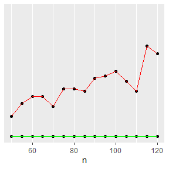

```r
library(ggplot2)

dCov <- function(x, y) {
  x <- as.matrix(x)
  y <- as.matrix(y)
  n <- nrow(x)
  m <- nrow(y)
  if (n != m || n < 2) stop("Sample sizes must agree")
  if (! (all(is.finite(c(x, y))))) stop("Data contains missing or infinite values")

  Akl <- function(x) {
    d <- as.matrix(dist(x))
    m <- rowMeans(d)
    M <- mean(d)
    a <- sweep(d, 1, m)
    b <- sweep(a, 2, m)
    return(b + M)
    }
  A <- Akl(x)
  B <- Akl(y)
  dCov <- sqrt(mean(A * B))
  dCov
}


ndCov2 <- function(z, ix, dims) { #dims contains dimensions of x and y
  p <- dims[1]
  q <- dims[2]
  d <- p + q
  x <- z[ , 1:p] #leave x as is
  y <- z[ix, -(1:p)] #permute rows of y
  return(nrow(z) * dCov(x, y)^2)
  }

alpha <- 0.01
n <- c(seq(50,120,5))
m <- 50


set.seed(12345)


pow_dCor_Model1<-pow_ball_Model1<-pow_dCor_Model2<-pow_ball_Model2<-numeric(length(n))
dcor1<-dcor2<-p_ball1<-p_ball2<-numeric(m)

for (j in 1:length(n)) {


  for (i in 1:m) {

    set.seed(i)

    X<-mvrnorm(n[j],rep(0,2),diag(2))
    e<-mvrnorm(n[j],rep(0,2),diag(2))
    Y1<-(X/4)+e
    Z1<-cbind(X,Y1)
    Y2<-(X/4)*e
    Z2<-cbind(X,Y2)

    #model 1
    t1<-bcov.test(X,Y1,R=100)
    p_ball1[i]<-t1$p.value
    boot.obj1<-boot(data=Z1,statistic=ndCov2,R=100,sim="permutation",dims=c(2, 2))
    temp1<-c(boot.obj1$t0, boot.obj1$t)
    dcor1[i]<-mean(temp1>=temp1[1])

    #model 2
    t2<-bcov.test(X,Y2,R=100)
    p_ball2[i]<-t2$p.value
    boot.obj2<-boot(data=Z2,statistic=ndCov2,R=100,sim="permutation",dims=c(2, 2))
    temp2<-c(boot.obj2$t0, boot.obj2$t)
    dcor2[i]<-mean(temp2>=temp2[1])

    }
  pow_dCor_Model1[j]<-mean(dcor1<alpha)
  pow_ball_Model1[j]<-mean(p_ball1<alpha)
  pow_dCor_Model2[j]<-mean(dcor2<alpha)
  pow_ball_Model2[j]<-mean(p_ball2<alpha)
}

dat1<-data.frame(pow_dCor_Model1,pow_ball_Model1)

ggplot(dat1,aes(n))+geom_point(y=pow_dCor_Model1,fill="white")+geom_line(y=pow_dCor_Model1,colour="red")+geom_point(y=pow_ball_Model1,fill="white")+geom_line(y=pow_ball_Model1,colour="green")
```

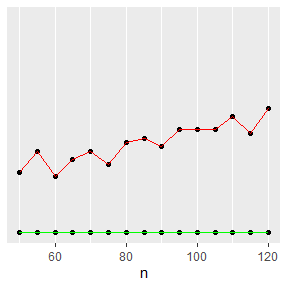

```r
dat2<-data.frame(pow_dCor_Model2,pow_ball_Model2)

ggplot(dat2,aes(n))+geom_point(y=pow_dCor_Model2,fill="white")+geom_line(y=pow_dCor_Model2,colour="red")+geom_point(y=pow_ball_Model2,fill="white")+geom_line(y=pow_ball_Model2,colour="green")
```

# A-19023-2019-11-29

## Qustion

$9.4$ Implement a random walk Metropolis sampler for generating the standard Laplace distribution (see Exercise 3.2). For the increment, simulate from a normal distribution. Compare the chains generated when different variances are used for the proposal distribution. Also, compute the acceptance rates of each chain.

##Answer

```r
dt <- function(t){
  exp(-abs(t))
}

rw.Metropolis <- function(sigma, x0, N) {
  x <- numeric(N)
  x[1] <- x0
  u <- runif(N)
  k <- 0
  for (i in 2:N) {
    y <- rnorm(1, x[i-1], sigma)
    if (u[i] <= (dt(y) / dt(x[i-1])))
      x[i] <- y else {
        x[i] <- x[i-1]
        k <- k + 1
        }
    }
  return(list(x=x, k=k))
  }

N <- 2000
sigma <- c(.05, .5, 2, 16)
x0 <- 25
rw1 <- rw.Metropolis(sigma[1], x0, N)
rw2 <- rw.Metropolis(sigma[2], x0, N)
rw3 <- rw.Metropolis(sigma[3], x0, N)
rw4 <- rw.Metropolis(sigma[4], x0, N)

rw <- c(rw1$k, rw2$k, rw3$k, rw4$k)
rej <- rw/N
rec <- 1-rej
m <- matrix(0, 2, 4)
rownames(m) <- c("rejection","reception")
colnames(m) <- NULL
m[1,] <- rej
m[2,] <- rec
m
```

```
##             [,1]   [,2]   [,3]   [,4]
## rejection 0.0165 0.1595 0.4815 0.8955
## reception 0.9835 0.8405 0.5185 0.1045
```

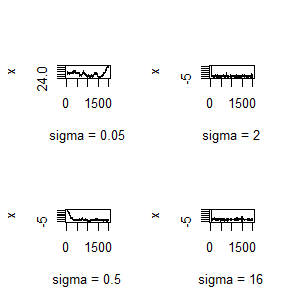

```r
a <- 1:2000
par(mar = c(4,4,4,2)+0.1,mfcol=c(2,2))
plot(a, rw1$x, type = "s", main = "", xlab = "sigma = 0.05", ylab = "x")
plot(a, rw2$x, type = "s", main = "", xlab = "sigma = 0.5", ylab = "x")
plot(a, rw3$x, type = "s", main = "", xlab = "sigma = 2", ylab = "x")
plot(a, rw4$x, type = "s", main = "", xlab = "sigma = 16", ylab = "x")
```

When $\sigma=2$,the rejection rate is within [0.15. 0.5], and it converges to the target function in a short amount of time.

# A-19023-2019-12-06

## Qustion 1

11.1 The natural logarithm and exponential functions are inverses of each other,so that mathematically log(exp x) = exp(log x) = x. Show by example that this property does not hold exactly in computer arithmetic. Does the identity hold with near equality? (See all.equal.)

## Answer

```r
x <- numeric(100)

isTRUE(identical(log(exp(x)),exp(log(x))))
```

```
## [1] TRUE
```

```r
isTRUE(all.equal(log(exp(x)),exp(log(x))))
```

```
## [1] TRUE
```

## Qustion 2

11.5 Write a function to solve the equation

$$\frac{2Γ({k\over2})}{\sqrt{\pi(k-1)}Γ(\frac{k-1}{2})}\int_0^{c_{k-1}}({1+\frac{u^2}{k-1}})^{-k/2}du=\frac{2Γ({k+1\over2})}{\sqrt{\pi(k)}Γ(\frac{k}{2})}\int_0^{c_{k}}(1+\frac{u^2}{k})^{-(k+1)/2}du$$

for a, where

$$c_k=\sqrt{\frac{a^2k}{k+1-a^2}}$$
Compare the solutions with the points A(k) in Exercise 11.4.

## Answer

```r
k <- 100

g <- function(v){
  return(exp(log(2)+lgamma(v/2)-(1/2)*(log(pi * (v-1)))-lgamma((v-1)/2)))
  }

f <- function(a)
  (g(k)*integrate(function(u)(1 + (u^2)/(k-1))^(-k/2),lower = 0,upper =sqrt((a^2)*(k-1)/(k-a^2)))$value)-(g(k+1)*integrate(function(u)(1+(u^2)/k)^(-(k+1)/2),lower = 0,upper = sqrt((a^2)*k/(k+1-a^2)))$value)

out <- uniroot(f,lower = 0.1,upper = 1+sqrt(k)/2)

out
```

```
## $root
## [1] 1.720614
##
## $f.root
## [1] 4.186996e-10
##
## $iter
## [1] 9
##
## $init.it
## [1] NA
##
## $estim.prec
## [1] 6.103516e-05
```

## Qustion 3

## A-B-O blood type problem

Let the three alleles be A, B, and O with allele frequencies p,q, and r. The 6 genotype frequencies under HWE and complete counts are as follows.

Observed data: nA· = nAA + nAO = 28 (A-type),nB· = nBB + nBO = 24 (B-type), nOO = 41 (O-type),nAB = 70 (AB-type).

1. Use EM algorithm to solve MLE of p and q (consider missing data nAA and nBB).
2. Show that the log-maximum likelihood values in M-steps are increasing via line plot.

## Answer

```r
n_A <- 28; n_B <- 24; n_OO <- 41; n_AB <- 70

p <- q <- r <- numeric(100)

p[1] <- 0.2
q[1] <- 0.2
r[1] <- (1- p[1]- q[1])

f1 <- function(a,b) {
   return((n_B*b/(2-b-2*a)+n_B+n_AB)/(n_A*a/(2-a-2*b)+n_A+n_AB))
}

f2 <- function(a,b) {
   return(((1-a/(2-a-2*b))*n_A+(1-b/(2-b-2*a))*n_B+2*n_OO)/((n_B*b/(2-b-2*a)+
                          n_B+n_AB)))
}
threshold <- 1e-5


for (k in 2:100) {
   p[k] <- 1/(1+f1(p[k-1],q[k-1])*(1+f2(p[k-1],q[k-1])))
   q[k] <- f1(p[k-1],q[k-1])/(1+f1(p[k-1],q[k-1])*(1+f2(p[k-1],q[k-1])))
   r[k] <- 1- p[k] - q[k]
   #The iterative relation is obtained by EM algorithm
   if((p[k]-p[k-1] <= threshold) & (q[k]-q[k-1] <= threshold) & (r[k]-r[k-1] <= threshold))
      {print(c(k, p[k], q[k],r[k]))
      break
      }
   }
```

```
## [1] 7.0000000 0.3273433 0.3104259 0.3622308
```

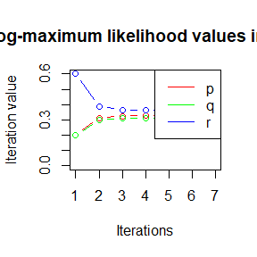

```r
x <- seq(1,k,1)

plot(x, p[1:k], "b", col = "red",ylim=c(0,0.6), xlab = "Iterations", ylab = "Iteration value", main = "The log-maximum likelihood values in M-steps")
lines(x, q[1:k], "b", col = "green")
lines(x, r[1:k], "b", col = "blue")
legend("topright", legend = c("p", "q", "r"),lty = 1, col = c("red", "green", "blue"))
```

# A-19023-2019-12-13

## Qustion 1

11.1.2.3 Use both for loops and lapply() to fit linear models to the mtcars using the formulas stored in this list:

formulas <- list( mpg ~ disp, mpg ~ I(1 / disp), mpg ~ disp + wt, mpg ~ I(1 / disp) + wt )

## Answer

```r
formulas <- list(
  mpg ~ disp,
  mpg ~ I(1 / disp),
  mpg ~ disp + wt,
  mpg ~ I(1 / disp) + wt
)

f1 <- lapply(formulas, lm, data = mtcars)
f2 <- lapply(formulas, function(x) lm(formula = x, data = mtcars))

#loop
lf1 <- vector("list", length(formulas))
for (i in seq_along(formulas)){
  lf1[[i]] <- lm(formulas[[i]], data = mtcars)
}
```

## Qustion 2

11.1.2.4 Fit the model mpg ~ disp to each of the bootstrap replicates of mtcars in the list below by using a for loop and lapply().Can you do it without an anonymous function?

bootstraps <- lapply(1:10, function(i) { rows <- sample(1:nrow(mtcars), rep = TRUE) mtcars[rows, ] })

## Answer

```r
bootstraps <- lapply(1:10, function(i) {
  rows <- sample(1:nrow(mtcars), rep = TRUE)
  mtcars[rows, ]
})

#without an anonymous function
f <- lapply(bootstraps, lm, formula = mpg ~ disp)

#loop
lf <- vector("list", length(bootstraps))
for (i in seq_along(bootstraps)){
  lf[[i]] <- lm(mpg ~ disp, data = bootstraps[[i]])
}
```

## Qustion 3

11.1.2.5 For each model in the previous two exercises, extract $R^2$ using the function below.

rsq <- function(mod) summary(mod)$r.squared

## Answer

```r
rsq <- function(mod) summary(mod)$r.squared

#in the exercise3
sapply(f1, rsq)
```

```
## [1] 0.7183433 0.8596865 0.7809306 0.8838038
```

```r
sapply(f2, rsq)
```

```
## [1] 0.7183433 0.8596865 0.7809306 0.8838038
```

```r
sapply(lf1, rsq)
```

```
## [1] 0.7183433 0.8596865 0.7809306 0.8838038
```

```r
#in the exercise4
sapply(f, rsq)
```

```
##  [1] 0.6301265 0.7415964 0.7309397 0.7765654 0.6575421 0.7412122 0.8179584
##  [8] 0.8282143 0.6734918 0.6792444
```

```r
sapply(lf, rsq)
```

```
##  [1] 0.6301265 0.7415964 0.7309397 0.7765654 0.6575421 0.7412122 0.8179584
##  [8] 0.8282143 0.6734918 0.6792444
```

## Qustion 4

11.2.5.3 The following code simulates the performance of a t-test for non-normal data. Use sapply() and an anonymous function to extract the p-value from every trial.

trials <- replicate( 100, t.test(rpois(10, 10), rpois(7, 10)), simplify = FALSE )

Extra challenge: get rid of the anonymous function by using [[ directly.

## Answer

```r
trials <- replicate(
  100,
  t.test(rpois(10, 10), rpois(7, 10)),
  simplify = FALSE
)

# anonymous function
sapply(trials, function(x) x[["p.value"]])
```

```
##   [1] 0.52273581 0.87886110 0.66990937 0.40112261 0.73250946 0.22431374
##   [7] 0.20059031 0.43047124 0.32325147 0.44549431 0.59855194 0.44368787
##  [13] 0.86230514 0.00863986 0.47087024 0.12014639 0.91313000 0.75254927
##  [19] 0.93560190 0.12442292 0.72162469 0.41204434 0.69767801 0.24221640
##  [25] 0.03125785 0.12002806 0.74133069 0.90187395 0.39132794 0.76857582
##  [31] 0.85984327 0.80992965 0.51302232 0.08632217 0.29019840 0.53499987
##  [37] 0.56807325 1.00000000 0.08512248 0.26681407 0.03320767 0.08637273
##  [43] 0.59314053 0.58492159 0.12647697 0.42291679 0.42541919 0.10471723
##  [49] 0.52698132 0.29306484 0.97205543 0.26048229 0.38919355 0.22907422
##  [55] 0.81768007 0.01147536 0.99270142 0.93749926 0.55357404 0.11242918
##  [61] 0.39735171 0.21713585 0.91496542 0.39554430 0.42857648 0.75357601
##  [67] 0.68968663 0.45651374 0.39814917 0.75052236 0.12059287 0.19202301
##  [73] 0.75044715 0.35462539 0.89080983 0.40670488 0.26432212 0.41902905
##  [79] 0.93026603 0.05250418 0.50029039 0.41292488 0.35748803 0.06639957
##  [85] 0.33930115 0.10986118 0.21318481 0.50534848 0.64643628 0.86249600
##  [91] 0.22616132 0.41501401 0.31276597 0.09267209 0.72169820 0.66242152
##  [97] 0.54850201 0.68332038 0.83918840 0.54848460
```

```r
# without anonymous function
sapply(trials, "[[", "p.value")
```

```
##   [1] 0.52273581 0.87886110 0.66990937 0.40112261 0.73250946 0.22431374
##   [7] 0.20059031 0.43047124 0.32325147 0.44549431 0.59855194 0.44368787
##  [13] 0.86230514 0.00863986 0.47087024 0.12014639 0.91313000 0.75254927
##  [19] 0.93560190 0.12442292 0.72162469 0.41204434 0.69767801 0.24221640
##  [25] 0.03125785 0.12002806 0.74133069 0.90187395 0.39132794 0.76857582
##  [31] 0.85984327 0.80992965 0.51302232 0.08632217 0.29019840 0.53499987
##  [37] 0.56807325 1.00000000 0.08512248 0.26681407 0.03320767 0.08637273
##  [43] 0.59314053 0.58492159 0.12647697 0.42291679 0.42541919 0.10471723
##  [49] 0.52698132 0.29306484 0.97205543 0.26048229 0.38919355 0.22907422
##  [55] 0.81768007 0.01147536 0.99270142 0.93749926 0.55357404 0.11242918
##  [61] 0.39735171 0.21713585 0.91496542 0.39554430 0.42857648 0.75357601
##  [67] 0.68968663 0.45651374 0.39814917 0.75052236 0.12059287 0.19202301
##  [73] 0.75044715 0.35462539 0.89080983 0.40670488 0.26432212 0.41902905
##  [79] 0.93026603 0.05250418 0.50029039 0.41292488 0.35748803 0.06639957
##  [85] 0.33930115 0.10986118 0.21318481 0.50534848 0.64643628 0.86249600
##  [91] 0.22616132 0.41501401 0.31276597 0.09267209 0.72169820 0.66242152
##  [97] 0.54850201 0.68332038 0.83918840 0.54848460
```

## Qustion 5

11.2.5.7 Implement mcsapply(), a multicore version of sapply(). Can you implement mcvapply(), a parallel version of vapply()? Why or why not?

## Answer

1.parSapply()’s effect is the same as mcsapply(),it is also a parallel version of sapply().

```r
f <- function(x){
  return(x+1)
}

#parSapply
library(parallel)

cl <- makeCluster(getOption('cl.cores', 4));
parSapply(cl, 1:500, f)
```

```
##   [1]   2   3   4   5   6   7   8   9  10  11  12  13  14  15  16  17  18  19
##  [19]  20  21  22  23  24  25  26  27  28  29  30  31  32  33  34  35  36  37
##  [37]  38  39  40  41  42  43  44  45  46  47  48  49  50  51  52  53  54  55
##  [55]  56  57  58  59  60  61  62  63  64  65  66  67  68  69  70  71  72  73
##  [73]  74  75  76  77  78  79  80  81  82  83  84  85  86  87  88  89  90  91
##  [91]  92  93  94  95  96  97  98  99 100 101 102 103 104 105 106 107 108 109
## [109] 110 111 112 113 114 115 116 117 118 119 120 121 122 123 124 125 126 127
## [127] 128 129 130 131 132 133 134 135 136 137 138 139 140 141 142 143 144 145
## [145] 146 147 148 149 150 151 152 153 154 155 156 157 158 159 160 161 162 163
## [163] 164 165 166 167 168 169 170 171 172 173 174 175 176 177 178 179 180 181
## [181] 182 183 184 185 186 187 188 189 190 191 192 193 194 195 196 197 198 199
## [199] 200 201 202 203 204 205 206 207 208 209 210 211 212 213 214 215 216 217
## [217] 218 219 220 221 222 223 224 225 226 227 228 229 230 231 232 233 234 235
## [235] 236 237 238 239 240 241 242 243 244 245 246 247 248 249 250 251 252 253
## [253] 254 255 256 257 258 259 260 261 262 263 264 265 266 267 268 269 270 271
## [271] 272 273 274 275 276 277 278 279 280 281 282 283 284 285 286 287 288 289
## [289] 290 291 292 293 294 295 296 297 298 299 300 301 302 303 304 305 306 307
## [307] 308 309 310 311 312 313 314 315 316 317 318 319 320 321 322 323 324 325
## [325] 326 327 328 329 330 331 332 333 334 335 336 337 338 339 340 341 342 343
## [343] 344 345 346 347 348 349 350 351 352 353 354 355 356 357 358 359 360 361
## [361] 362 363 364 365 366 367 368 369 370 371 372 373 374 375 376 377 378 379
## [379] 380 381 382 383 384 385 386 387 388 389 390 391 392 393 394 395 396 397
## [397] 398 399 400 401 402 403 404 405 406 407 408 409 410 411 412 413 414 415
## [415] 416 417 418 419 420 421 422 423 424 425 426 427 428 429 430 431 432 433
## [433] 434 435 436 437 438 439 440 441 442 443 444 445 446 447 448 449 450 451
## [451] 452 453 454 455 456 457 458 459 460 461 462 463 464 465 466 467 468 469
## [469] 470 471 472 473 474 475 476 477 478 479 480 481 482 483 484 485 486 487
## [487] 488 489 490 491 492 493 494 495 496 497 498 499 500 501
```

```r
stopCluster(cl)
```

2.Mcvapply() cannot be implemented on Windows.

# A-19023-2019-12-20

## Questions

##1 You have already written an R function for Exercise 9.4 (page 277, Statistical Computing with R). Rewrite an Rcpp function for the same task.

## Answer1

*This is the Rcpp function for the rw_Metropolis.

```r
library(Rcpp)

cppFunction('NumericVector rwMetropolisC(double sigma, double x0, double N) {
  NumericVector x(N+1);
  x[0] = x0;
  NumericVector u = runif(N);
  double k = 0;
  double y = 0;
  for (int i = 2; i < N+1; i++) {
    y = rnorm(1, x[i-2], sigma)[0];
    if (u[i-2] <= exp(-((abs(y))-(abs(x[i-2])))) ) {
      x[i-1] = y;
    }
    else {
      x[i-1] = x[i-2];
      k++;
    }
  }
  x[N] = k;
  return(x);
}')

N <- 2000
sigma <- c(.05, .5, 2, 16)
x0 <- 25
set.seed(12345)
rwC1 <- rwMetropolisC(sigma[1], x0, N)
rwC2 <- rwMetropolisC(sigma[2], x0, N)
rwC3 <- rwMetropolisC(sigma[3], x0, N)
rwC4 <- rwMetropolisC(sigma[4], x0, N)
rwC <- cbind(rwC1[-(N+1)], rwC2[-(N+1)], rwC3[-(N+1)], rwC4[-(N+1)])

#the acceptance rates
print(c(1-rwC1[N+1]/N,1-rwC2[N+1]/N,1-rwC3[N+1]/N,1-rwC4[N+1]/N))
```

```
## [1] 0.9850 0.8615 0.5730 0.1140
```

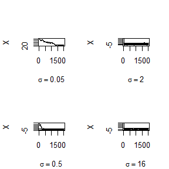

```r
par(mar = c(4,4,4,2)+0.1,mfcol = c(2, 2))
refline <- c(log(2 * .025), -log(2 * (1 - .975)))
for (j in 1:4) {
  plot(rwC[, j], type = 'l', xlab = bquote(sigma == .(round(sigma[j], 3))), ylab = 'X', ylim = range(rwC[, j]))
  abline(h = refline)
}
```

*This is the R function for the rw_Metropolis.

```r
dt <- function(t){
  exp(-abs(t))
}


rw.Metropolis <- function(sigma, x0, N) {
  x <- numeric(N)
  x[1] <- x0
  u <- runif(N)
  k <- 0
  for (i in 2:N) {
    y <- rnorm(1, x[i-1], sigma)
    if (u[i] <= (dt(y) / dt(x[i-1])))
      x[i] <- y else {
        x[i] <- x[i-1]
        k <- k + 1
        }
    }
  return(list(x=x, k=k))
  }

N <- 2000
sigma <- c(.05, .5, 2, 16)
x0 <- 25
rw1 <- rw.Metropolis(sigma[1], x0, N)
rw2 <- rw.Metropolis(sigma[2], x0, N)
rw3 <- rw.Metropolis(sigma[3], x0, N)
rw4 <- rw.Metropolis(sigma[4], x0, N)

rw <- c(rw1$k, rw2$k, rw3$k, rw4$k)
rej <- rw/N
rec <- 1-rej
m <- matrix(0, 2, 4)
rownames(m) <- c("rejection","reception")
colnames(m) <- NULL
m[1,] <- rej
m[2,] <- rec
m
```

```
##            [,1]  [,2]  [,3]  [,4]
## rejection 0.018 0.173 0.457 0.887
## reception 0.982 0.827 0.543 0.113
```

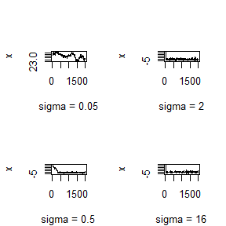

```r
a <- 1:2000
par(mar = c(4,4,4,2)+0.1,mfcol=c(2,2))
plot(a, rw1$x, type = "s", main = "", xlab = "sigma = 0.05", ylab = "x")
plot(a, rw2$x, type = "s", main = "", xlab = "sigma = 0.5", ylab = "x")
plot(a, rw3$x, type = "s", main = "", xlab = "sigma = 2", ylab = "x")
plot(a, rw4$x, type = "s", main = "", xlab = "sigma = 16", ylab = "x")
```

##2 Compare the generated random numbers by the two functions using qqplot.

## Answer2

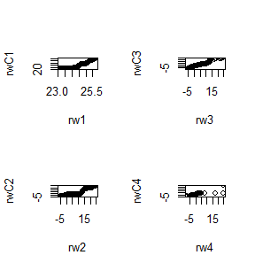

```r
par(mar = c(4,4,4,2)+0.1,mfcol = c(2, 2))
qqplot(rw1$x, rwC1[-(N+1)], xlab = 'rw1', ylab = 'rwC1')
qqplot(rw2$x, rwC2[-(N+1)], xlab = 'rw2', ylab = 'rwC2')
qqplot(rw3$x, rwC3[-(N+1)], xlab = 'rw3', ylab = 'rwC3')
qqplot(rw4$x, rwC4[-(N+1)], xlab = 'rw4', ylab = 'rwC4')
```

##3 Compare the computation time of the two functions with microbenchmark.

## Answer3

```r
library(microbenchmark)

ts <- microbenchmark(rwC1 = rwMetropolisC(sigma[1], x0, N), rwC2 = rwMetropolisC(sigma[2], x0, N), rwC3 = rwMetropolisC(sigma[3], x0, N), rwC4 = rwMetropolisC(sigma[4], x0, N), rw1 = rw.Metropolis(sigma[1], x0, N), rw2 = rw.Metropolis(sigma[2], x0, N), rw3 = rw.Metropolis(sigma[3], x0, N), rw4 = rw.Metropolis(sigma[4], x0, N))
knitr::kable(summary(ts)[, c(1,3,5,6)])
```

| expr | lq | median | uq |
| --- | --- | --- | --- |
| rwC1 | 159.40 | 161.05 | 163.15 |
| rwC2 | 187.90 | 190.10 | 192.50 |
| rwC3 | 231.25 | 232.85 | 234.75 |
| rwC4 | 237.75 | 239.10 | 240.50 |
| rw1 | 4774.35 | 4790.20 | 4813.90 |
| rw2 | 4827.55 | 4853.90 | 4902.55 |
| rw3 | 4863.10 | 4884.85 | 4909.90 |
| rw4 | 4894.35 | 4914.65 | 4957.00 |

##4 Comments your results.

## Answer4

According to the results,the Rcpp function’s result takes less computational time than R function.